# inlinehelp_view_study_info_overview_de-deu – IRTlib

### Einstellungen zur Studie

- **Bezeichnung**: Wie soll die *Studie* benannt werden? Achten Sie darauf, dass für die Bezeichnung nur Buchstaben (Groß- und Kleinbuchstaben), Ziffern und ein `_` erlaubt sind.
- **Beschreibung**: Um eine ausführliche Beschreibung der *Studie* hinterlegen zu können, ist dieses optionle Feld vorgesehen. Hier können auch Sonderzeichen und Umlaute usw. eingegeben werden.
- **Routing für Erhebungsteile aktivieren**: *Studien* bestehen aus einem oder mehreren *Erhebungsteilen*. Die *Erhebungsteile* werden per Default als lineare Abfolge administriert. Wenn die Option *Routing für Erhebungsteile aktivieren* ausgewählt ist, kann die Reihenfolge der *Erhebungsteile* mit einem *Blockly*-basierten Routing definiert werden. Dadurch sind dynamische Abfolgen von *Erhebungsteilen* möglich, wobei auch Aufrufparameter der Studie bspw. für die Zuordnung von unterschiedlichen Reihenfolgen genutzt werden können.
- **Bildschirmgröße überprüfen**: In Erhebungen, bei denen die Bildschirmgröße nicht bekannt ist, kann mit dieser Option ein Größenvergleich von Objekten (EC-Karte, Banknote, Personalausweis) mit Darstellungen auf dem Bildschirm vorgenommen werden.

> Die Geräteprüfung erfolgt mit folgendem Dialog:

[figure not shown]

> Wenn die Option *Passende Bildschirmgröße erzwingen* (im Abschnitt *Anzeige*) nicht aktiviert ist, dann kann die Testbearbeitung dennoch begonnen werden. Es wird, wenn die Auflösung zu klein ist, folgender Dialog angezeigt:

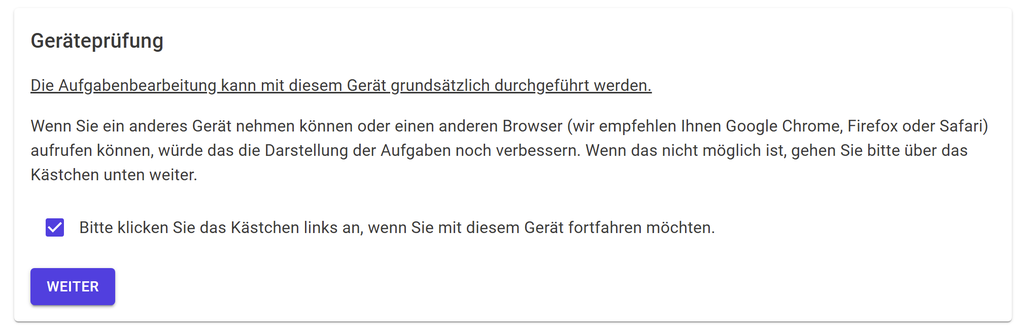

> Hinweis: Diese Option ist zur Zeit nicht weiter konfigurierbar.

Wenn geänderte Einstellungen erhalten bleiben sollen müssen die Änderungen über das Disketten-Symbol gespeichert werden. Andernfalls kann das Verwerfen-Symbol verwendet werden: